# Forschungsbericht Mediennetzwerk Profi- und Amateurfussballvereine Baden-Württemberg

## 3.5 Zentralitätsmaße

Im folgenden Abschnitt sollen einige Zentralitätsmaße genauer untersucht werden. Dazu zählen Degree, Betweenness und Broker, Closeness und ein Spezialfall zur Analyse besonders einflussreicher Knoten.

Je nach Auswahl des Netzwerks unterscheiden sich die Analyseergebnisse stark. Deshalb ist es notwendig, zunächst zu klären, welche Netzwerke untersucht werden sollen.

```r
library(igraph)
library(visNetwork)

# Einlesen der Edge- und Nodelist
edges <- read.csv("https://raw.githubusercontent.com/JulianR2406/Football-Media/refs/heads/main/footballmedia_edges.csv", header=T, as.is=T, sep = ",")

nodes <- read.csv("https://raw.githubusercontent.com/JulianR2406/Football-Media/refs/heads/main/footballmedia_nodes.csv", header=T, as.is=T, sep = ",")

# Erstellen einer Matrix
edgematrix <-as.matrix(edges)

# Zusammenführen von Edge- und Nodelist als igraph-Objekt footballmedia
footballmedia <- graph_from_data_frame(d=edgematrix, vertices=nodes, directed=F)
footballmedia
```

```
## IGRAPH 173db4d UNWB 199 472 --
## + attr: name (v/c), type (v/c), liga (v/c), rechtsform (v/c), verband
## | (v/c), media (v/c), reichweite (v/c), weight (e/c), liga (e/c),
## | category (e/c)
## + edges from 173db4d (vertex names):
##  [1] ARD             --sportschau          ARD             --SWR
##  [3] Axel Springer   --BILD                WELT            --Axel Springer
##  [5] BFV             --FC Astoria Walldorf BFV             --Karlsruher SC
##  [7] BFV             --SV Sandhausen       BFV             --SV Waldhof Mannheim
##  [9] BFV             --TSG Hoffenheim      aufwind Group   --Bahlinger SC
## [11] Badische Zeitung--Bahlinger SC        FuPa            --Bahlinger SC
## + ... omitted several edges
```

### 3.5.1 Degree

**Degree-Werte allgemein** Analyse des Knotens mit den häufigsten starken Beziehungen:

```r
# Knoten mit den stärksten Beziehungen im Gesamtnetzwerk
degree(footballmedia, mode="all")
```

```
##          Rund um den Brustring                   Vertikalpass
##                              1                              1
##                   vfb exklusiv                    ART TAPETEN
##                              1                              1
##             Baier DigitalDruck            Bairle Druck Medien
##                              1                              1
##                     DRUCKtuell                Druckhaus Frank
##                              1                              1
##         Druckerei Furtwaengler                       Grom Ilg
##                              1                              1
##            Hummel Werbetechnik              Kniebuehler Druck
##                              1                              1
##                Druckerei Leute         Manhillen Drucktechnik
##                              1                              1
##            Druckerei Memminger                     RO Werbung
##                              1                              1
##             Schaa Digitaldruck                 Schwall Medien
##                              2                              1
##                 Werbepunkt Ulm         Druck Medien Zipperlen
##                              1                              1
##                     baden film             Pressefoto baumann
##                              1                              1
##                   Bildbrauerei                  CTS sportfoto
##                              1                              1
##              Eibner Pressefoto                     entermedia
##                              1                              1
##             Flutlicht-Film OHG                Jaeger und Kies
##                              1                              1
##                 WW ModernMedia                   raumSicht360
##                              1                              1
##                       Suedfilm                  Felix Steiner
##                              1                              1
##                  TB Sportphoto                          Zone7
##                              1                              1
##                Electronic Arts                   Agentur Neun
##                              2                              1
##                  amici Agentur                   BLIM Agentur
##                              1                              1
##                      Convensis                   DIGITALFEUER
##                              1                              1
```

[output cut: 145 more lines]

```
##                             10                             52
##                   FC Villingen                  Goeppinger SV
##                             15                             17
##                  Karlsruher SC                           SBFV
##                             45                              4
##                    SC Freiburg                   SGV Freiberg
##                             46                             11
##            Stuttgarter Kickers                  SV Sandhausen
##                             25                             27
##            SV Waldhof Mannheim                 TSG Hoffenheim
##                             30                             45
##               SSV Ulm Fussball                  VfB Stuttgart
##                             40                             45
##                            WFV
##                              7
```

```r
which.max(degree(footballmedia, mode="all"))
```

```
## FC Heidenheim
##           186
```

```r
# Teilnetzwerke
# 1. Profvereine
degree(pro, mode="all")
```

```
##          Rund um den Brustring                   Vertikalpass
##                              1                              1
##                   vfb exklusiv                    ART TAPETEN
##                              1                              1
##            Bairle Druck Medien                     DRUCKtuell
##                              1                              1
##                Druckhaus Frank         Druckerei Furtwaengler
##                              1                              1
##            Hummel Werbetechnik             Schaa Digitaldruck
##                              1                              1
##                 Schwall Medien                 Werbepunkt Ulm
##                              1                              1
##         Druck Medien Zipperlen                     entermedia
##                              1                              1
##             Flutlicht-Film OHG                  Felix Steiner
##                              1                              1
##                   Agentur Neun                  amici Agentur
##                              1                              1
##                   DIGITALFEUER                Garden of Youth
##                              1                              1
##      Karlsruhe Marketing Event                     Muenchrath
##                              1                              1
##                       SocialMe                    DIENEUE1077
##                              1                              1
##                 die neue welle                       Donau3FM
##                              1                              1
##                         Radio7               Radio Regenbogen
##                              1                              1
##                           SWR1                      Radio Ton
##                              4                              1
##                           DAZN                        BadenTV
##                              4                              1
##                      Eurosport                           RAN
##                              4                              6
##                        regioTV         Rhein-Neckar Fernsehen
##                              1                              1
##                            RTL                Sky Deutschland
##                              1                              6
##                         Sport1                     sportschau
##                              6                              6
```

[output cut: 55 more lines]

```
##                              1                              4
##                         watson                           Zeit
##                              4                              4
##      Zeitungsverlag Waiblingen                            BFV
##                              6                              2
##                            DFL                  FC Heidenheim
##                              6                             52
##                  Karlsruher SC                           SBFV
##                             45                              1
##                    SC Freiburg                 TSG Hoffenheim
##                             46                             45
##               SSV Ulm Fussball                  VfB Stuttgart
##                             40                             45
##                            WFV
##                              3
```

```r
which.max(degree(pro, mode="all"))
```

```
## FC Heidenheim
##           102
```

```r
# 2. Amateurvereine
degree(ama, mode="all")
```

```
##             Baier DigitalDruck                       Grom Ilg
##                              1                              1
##              Kniebuehler Druck                Druckerei Leute
##                              1                              1
##         Manhillen Drucktechnik            Druckerei Memminger
##                              1                              1
##                     RO Werbung             Schaa Digitaldruck
##                              1                              1
##             Pressefoto baumann                   Bildbrauerei
##                              1                              1
##                  CTS sportfoto              Eibner Pressefoto
##                              1                              1
##                Jaeger und Kies                 WW ModernMedia
##                              1                              1
##                   raumSicht360                       Suedfilm
##                              1                              1
##                  TB Sportphoto                          Zone7
##                              1                              1
##                   BLIM Agentur                      Convensis
##                              1                              1
##                      Highscore          imc marketing consult
##                              1                              1
##                     Jan Oelker                        madness
##                              1                              1
##                        METATOP                       newtmrrw
##                              1                              1
##                        saltico                       Sudhaus7
##                              1                              1
##                       antenne1                        LEAGUES
##                              2                              6
##                   filstalwelle                  magenta sport
##                              1                              2
##                           RAN                         regioTV
##                              8                              1
##         Rhein-Neckar Fernsehen     Rheinpfalz Odenwald Neckar
##                              1                              1
##                         Sport1                     sportschau
##                              2                              2
##                            SWR                           WELT
##                              2                              8
```

[output cut: 41 more lines]

```
##                              2                              1
##          WochenblattReporterDE      Zeitungsverlag Waiblingen
##                              1                              2
##                            BFV                   Bahlinger SC
##                              3                             14
##            FC Astoria Walldorf                   FC Villingen
##                             10                             15
##                  Goeppinger SV                           SBFV
##                             17                              2
##                   SGV Freiberg            Stuttgarter Kickers
##                             11                             25
##                  SV Sandhausen            SV Waldhof Mannheim
##                             27                             30
##                            WFV
##                              3
```

```r
which.max(degree(ama, mode="all"))
```

```
## SV Waldhof Mannheim
##                  94
```

Der Vergleich der Netzwerke hinsichtlich des **allgemeinen Degree-Werts** zeigt, dass im Gesamtnetzwerk der Knoten „FC Heidenheim“ mit einem Degree-Wert von 52 die meisten Verbindungen aufweist. Interessanterweise bleibt dies auch im Teilnetzwerk der Profivereine unverändert, da „FC Heidenheim“ mit ebenfalls 52 Verbindungen die stärkste Verknüpfung hat. Im Teilnetzwerk der Amateurvereine ist hingegen der Knoten „SV Waldhof Mannheim“ mit einem Degree-Wert von 30 der zentralste Akteur.

Da die absoluten Degree-Werte nur begrenzt aussagekräftig sind, wurde eine Normalisierung durchgeführt. Dabei wird der Degree-Wert eines Knotens ins Verhältnis zur Gesamtanzahl möglicher Verbindungen im jeweiligen Netzwerk gesetzt und als Prozentwert ausgedrückt. Diese Methode erlaubt präzisere Aussagen über die Rolle eines Knotens.

```r
# 1. Knoten mit den stärksten Beziehungen im Gesamtnetzwerk
degree(footballmedia, mode="all", normalized = TRUE)
```

```
##          Rund um den Brustring                   Vertikalpass
##                    0.005050505                    0.005050505
##                   vfb exklusiv                    ART TAPETEN
##                    0.005050505                    0.005050505
##             Baier DigitalDruck            Bairle Druck Medien
##                    0.005050505                    0.005050505
##                     DRUCKtuell                Druckhaus Frank
##                    0.005050505                    0.005050505
##         Druckerei Furtwaengler                       Grom Ilg
##                    0.005050505                    0.005050505
##            Hummel Werbetechnik              Kniebuehler Druck
##                    0.005050505                    0.005050505
##                Druckerei Leute         Manhillen Drucktechnik
##                    0.005050505                    0.005050505
##            Druckerei Memminger                     RO Werbung
##                    0.005050505                    0.005050505
##             Schaa Digitaldruck                 Schwall Medien
##                    0.010101010                    0.005050505
##                 Werbepunkt Ulm         Druck Medien Zipperlen
##                    0.005050505                    0.005050505
##                     baden film             Pressefoto baumann
##                    0.005050505                    0.005050505
##                   Bildbrauerei                  CTS sportfoto
##                    0.005050505                    0.005050505
##              Eibner Pressefoto                     entermedia
##                    0.005050505                    0.005050505
##             Flutlicht-Film OHG                Jaeger und Kies
##                    0.005050505                    0.005050505
##                 WW ModernMedia                   raumSicht360
##                    0.005050505                    0.005050505
##                       Suedfilm                  Felix Steiner
##                    0.005050505                    0.005050505
##                  TB Sportphoto                          Zone7
##                    0.005050505                    0.005050505
##                Electronic Arts                   Agentur Neun
##                    0.010101010                    0.005050505
##                  amici Agentur                   BLIM Agentur
##                    0.005050505                    0.005050505
##                      Convensis                   DIGITALFEUER
##                    0.005050505                    0.005050505
```

[output cut: 145 more lines]

```
##                    0.050505051                    0.262626263
##                   FC Villingen                  Goeppinger SV
##                    0.075757576                    0.085858586
##                  Karlsruher SC                           SBFV
##                    0.227272727                    0.020202020
##                    SC Freiburg                   SGV Freiberg
##                    0.232323232                    0.055555556
##            Stuttgarter Kickers                  SV Sandhausen
##                    0.126262626                    0.136363636
##            SV Waldhof Mannheim                 TSG Hoffenheim
##                    0.151515152                    0.227272727
##               SSV Ulm Fussball                  VfB Stuttgart
##                    0.202020202                    0.227272727
##                            WFV
##                    0.035353535
```

```r
which.max(degree(footballmedia, mode="all"))
```

```
## FC Heidenheim
##           186
```

```r
# 2. Teilnetzwerke
# 2.1 Profivereine
degree(pro, mode="all", normalized = TRUE)
```

```
##          Rund um den Brustring                   Vertikalpass
##                    0.009259259                    0.009259259
##                   vfb exklusiv                    ART TAPETEN
##                    0.009259259                    0.009259259
##            Bairle Druck Medien                     DRUCKtuell
##                    0.009259259                    0.009259259
##                Druckhaus Frank         Druckerei Furtwaengler
##                    0.009259259                    0.009259259
##            Hummel Werbetechnik             Schaa Digitaldruck
##                    0.009259259                    0.009259259
##                 Schwall Medien                 Werbepunkt Ulm
##                    0.009259259                    0.009259259
##         Druck Medien Zipperlen                     entermedia
##                    0.009259259                    0.009259259
##             Flutlicht-Film OHG                  Felix Steiner
##                    0.009259259                    0.009259259
##                   Agentur Neun                  amici Agentur
##                    0.009259259                    0.009259259
##                   DIGITALFEUER                Garden of Youth
##                    0.009259259                    0.009259259
##      Karlsruhe Marketing Event                     Muenchrath
##                    0.009259259                    0.009259259
##                       SocialMe                    DIENEUE1077
##                    0.009259259                    0.009259259
##                 die neue welle                       Donau3FM
##                    0.009259259                    0.009259259
##                         Radio7               Radio Regenbogen
##                    0.009259259                    0.009259259
##                           SWR1                      Radio Ton
##                    0.037037037                    0.009259259
##                           DAZN                        BadenTV
##                    0.037037037                    0.009259259
##                      Eurosport                           RAN
##                    0.037037037                    0.055555556
##                        regioTV         Rhein-Neckar Fernsehen
##                    0.009259259                    0.009259259
##                            RTL                Sky Deutschland
##                    0.009259259                    0.055555556
##                         Sport1                     sportschau
##                    0.055555556                    0.055555556
```

[output cut: 55 more lines]

```
##                    0.009259259                    0.037037037
##                         watson                           Zeit
##                    0.037037037                    0.037037037
##      Zeitungsverlag Waiblingen                            BFV
##                    0.055555556                    0.018518519
##                            DFL                  FC Heidenheim
##                    0.055555556                    0.481481481
##                  Karlsruher SC                           SBFV
##                    0.416666667                    0.009259259
##                    SC Freiburg                 TSG Hoffenheim
##                    0.425925926                    0.416666667
##               SSV Ulm Fussball                  VfB Stuttgart
##                    0.370370370                    0.416666667
##                            WFV
##                    0.027777778
```

```r
which.max(degree(pro, mode="all"))
```

```
## FC Heidenheim
##           102
```

```r
# 2.2 Amateurvereine
degree(ama, mode="all", normalized = TRUE)
```

```
##             Baier DigitalDruck                       Grom Ilg
##                     0.01063830                     0.01063830
##              Kniebuehler Druck                Druckerei Leute
##                     0.01063830                     0.01063830
##         Manhillen Drucktechnik            Druckerei Memminger
##                     0.01063830                     0.01063830
##                     RO Werbung             Schaa Digitaldruck
##                     0.01063830                     0.01063830
##             Pressefoto baumann                   Bildbrauerei
##                     0.01063830                     0.01063830
##                  CTS sportfoto              Eibner Pressefoto
##                     0.01063830                     0.01063830
##                Jaeger und Kies                 WW ModernMedia
##                     0.01063830                     0.01063830
##                   raumSicht360                       Suedfilm
##                     0.01063830                     0.01063830
##                  TB Sportphoto                          Zone7
##                     0.01063830                     0.01063830
##                   BLIM Agentur                      Convensis
##                     0.01063830                     0.01063830
##                      Highscore          imc marketing consult
##                     0.01063830                     0.01063830
##                     Jan Oelker                        madness
##                     0.01063830                     0.01063830
##                        METATOP                       newtmrrw
##                     0.01063830                     0.01063830
##                        saltico                       Sudhaus7
##                     0.01063830                     0.01063830
##                       antenne1                        LEAGUES
##                     0.02127660                     0.06382979
##                   filstalwelle                  magenta sport
##                     0.01063830                     0.02127660
##                           RAN                         regioTV
##                     0.08510638                     0.01063830
##         Rhein-Neckar Fernsehen     Rheinpfalz Odenwald Neckar
##                     0.01063830                     0.01063830
##                         Sport1                     sportschau
##                     0.02127660                     0.02127660
##                            SWR                           WELT
##                     0.02127660                     0.08510638
```

[output cut: 41 more lines]

```
##                     0.02127660                     0.01063830
##          WochenblattReporterDE      Zeitungsverlag Waiblingen
##                     0.01063830                     0.02127660
##                            BFV                   Bahlinger SC
##                     0.03191489                     0.14893617
##            FC Astoria Walldorf                   FC Villingen
##                     0.10638298                     0.15957447
##                  Goeppinger SV                           SBFV
##                     0.18085106                     0.02127660
##                   SGV Freiberg            Stuttgarter Kickers
##                     0.11702128                     0.26595745
##                  SV Sandhausen            SV Waldhof Mannheim
##                     0.28723404                     0.31914894
##                            WFV
##                     0.03191489
```

```r
which.max(degree(ama, mode="all"))
```

```
## SV Waldhof Mannheim
##                  94
```

Der Vergleich der Netzwerke anhand **der normalisierten Degree-Werte** zeigt folgendes Bild:

- Im Gesamtnetzwerk erreicht der „FC Heidenheim“ 26,26% der maximal möglichen Verbindungen.
- Im Teilnetzwerk der Profivereine erhöht sich dieser Wert auf 48,14%, da die Gesamtzahl der Knoten im Netzwerk geringer ist und der Verein relativ gesehen eine stärkere Position einnimmt.
- Im Teilnetzwerk der Amateurvereine hat der „SV Waldhof Mannheim“ mit 31,91% der möglichen Verbindungen die höchste Degree-Zentralität.

Die normalisierten Werte verdeutlichen, dass der „FC Heidenheim“ aufgrund seiner breiten Verbindungen sowohl im Gesamtnetzwerk als auch im Profibereich eine dominierende Rolle einnimmt. Im Gegensatz dazu zeigt der „SV Waldhof Mannheim“ im Amateurbereich seine überregionale Bedeutung durch eine vergleichsweise höhere Vernetzung als andere Amateurvereine. Dies resultiert vor allem aus seiner starken medialen Präsenz und zahlreichen offiziellen sowie inoffiziellen Partnerschaften, wodurch er Vereine wie den „SV Sandhausen“ oder Viertligisten deutlich übertrifft.

### 3.5.2 Betweeness und Broker im Netzwerk

Die **Betweenness-Zentralität** misst, wie wichtig ein Knoten als „Brücke“ für die Verbindungen zwischen anderen Knoten im Netzwerk ist. Sie zeigt, welche Akteure essenziell für die Vernetzung des Netzwerks sind.

```r
# Betweenness-Verteilung im Gesamtnetzwerk
betweenness(footballmedia, normalized = TRUE)
```

```
##          Rund um den Brustring                   Vertikalpass
##                   0.000000e+00                   0.000000e+00
##                   vfb exklusiv                    ART TAPETEN
##                   0.000000e+00                   0.000000e+00
##             Baier DigitalDruck            Bairle Druck Medien
##                   0.000000e+00                   0.000000e+00
##                     DRUCKtuell                Druckhaus Frank
##                   0.000000e+00                   0.000000e+00
##         Druckerei Furtwaengler                       Grom Ilg
##                   0.000000e+00                   0.000000e+00
##            Hummel Werbetechnik              Kniebuehler Druck
##                   0.000000e+00                   0.000000e+00
##                Druckerei Leute         Manhillen Drucktechnik
##                   0.000000e+00                   0.000000e+00
##            Druckerei Memminger                     RO Werbung
##                   0.000000e+00                   0.000000e+00
##             Schaa Digitaldruck                 Schwall Medien
##                   0.000000e+00                   0.000000e+00
##                 Werbepunkt Ulm         Druck Medien Zipperlen
##                   0.000000e+00                   0.000000e+00
##                     baden film             Pressefoto baumann
##                   0.000000e+00                   0.000000e+00
##                   Bildbrauerei                  CTS sportfoto
##                   0.000000e+00                   0.000000e+00
##              Eibner Pressefoto                     entermedia
##                   0.000000e+00                   0.000000e+00
##             Flutlicht-Film OHG                Jaeger und Kies
##                   0.000000e+00                   0.000000e+00
##                 WW ModernMedia                   raumSicht360
##                   0.000000e+00                   0.000000e+00
##                       Suedfilm                  Felix Steiner
##                   0.000000e+00                   0.000000e+00
##                  TB Sportphoto                          Zone7
##                   0.000000e+00                   0.000000e+00
##                Electronic Arts                   Agentur Neun
##                   0.000000e+00                   0.000000e+00
##                  amici Agentur                   BLIM Agentur
##                   0.000000e+00                   0.000000e+00
##                      Convensis                   DIGITALFEUER
##                   0.000000e+00                   0.000000e+00
```

[output cut: 145 more lines]

```
##                   1.469192e-02                   1.827534e-01
##                   FC Villingen                  Goeppinger SV
##                   6.096561e-02                   8.912595e-02
##                  Karlsruher SC                           SBFV
##                   1.612851e-01                   1.318552e-01
##                    SC Freiburg                   SGV Freiberg
##                   1.386163e-01                   4.010785e-02
##            Stuttgarter Kickers                  SV Sandhausen
##                   2.054421e-01                   5.275209e-02
##            SV Waldhof Mannheim                 TSG Hoffenheim
##                   9.212333e-02                   8.771309e-02
##               SSV Ulm Fussball                  VfB Stuttgart
##                   1.709197e-01                   1.399358e-01
##                            WFV
##                   3.461229e-01
```

```r
# Selektierung des Knotens mit dem höchsten Betweenness-Wert
which.max(betweenness(footballmedia))
```

```
## WFV
## 199
```

```r
# Betweenness-Verteilung im Teilnetzwerk Profivereine
betweenness(pro, normalized = TRUE)
```

```
##          Rund um den Brustring                   Vertikalpass
##                     0.00000000                     0.00000000
##                   vfb exklusiv                    ART TAPETEN
##                     0.00000000                     0.00000000
##            Bairle Druck Medien                     DRUCKtuell
##                     0.00000000                     0.00000000
##                Druckhaus Frank         Druckerei Furtwaengler
##                     0.00000000                     0.00000000
##            Hummel Werbetechnik             Schaa Digitaldruck
##                     0.00000000                     0.00000000
##                 Schwall Medien                 Werbepunkt Ulm
##                     0.00000000                     0.00000000
##         Druck Medien Zipperlen                     entermedia
##                     0.00000000                     0.00000000
##             Flutlicht-Film OHG                  Felix Steiner
##                     0.00000000                     0.00000000
##                   Agentur Neun                  amici Agentur
##                     0.00000000                     0.00000000
##                   DIGITALFEUER                Garden of Youth
##                     0.00000000                     0.00000000
##      Karlsruhe Marketing Event                     Muenchrath
##                     0.00000000                     0.00000000
##                       SocialMe                    DIENEUE1077
##                     0.00000000                     0.00000000
##                 die neue welle                       Donau3FM
##                     0.00000000                     0.00000000
##                         Radio7               Radio Regenbogen
##                     0.00000000                     0.00000000
##                           SWR1                      Radio Ton
##                     0.00000000                     0.00000000
##                           DAZN                        BadenTV
##                     0.00000000                     0.00000000
##                      Eurosport                           RAN
##                     0.00000000                     0.00000000
##                        regioTV         Rhein-Neckar Fernsehen
##                     0.00000000                     0.00000000
##                            RTL                Sky Deutschland
##                     0.00000000                     0.00000000
##                         Sport1                     sportschau
##                     0.00000000                     0.00000000
```

[output cut: 55 more lines]

```
##                     0.00000000                     0.00000000
##                         watson                           Zeit
##                     0.00000000                     0.00000000
##      Zeitungsverlag Waiblingen                            BFV
##                     0.00000000                     0.01467164
##                            DFL                  FC Heidenheim
##                     0.34440009                     0.26932727
##                  Karlsruher SC                           SBFV
##                     0.27095870                     0.00000000
##                    SC Freiburg                 TSG Hoffenheim
##                     0.17562845                     0.15717155
##               SSV Ulm Fussball                  VfB Stuttgart
##                     0.26427305                     0.18074413
##                            WFV
##                     0.05248936
```

```r
which.max(betweenness(pro))
```

```
## DFL
## 101
```

```r
# Betweenness-Verteilung im Teilnetzwerk Amateurvereine
betweenness(ama, normalized = TRUE)
```

```
##             Baier DigitalDruck                       Grom Ilg
##                     0.00000000                     0.00000000
##              Kniebuehler Druck                Druckerei Leute
##                     0.00000000                     0.00000000
##         Manhillen Drucktechnik            Druckerei Memminger
##                     0.00000000                     0.00000000
##                     RO Werbung             Schaa Digitaldruck
##                     0.00000000                     0.00000000
##             Pressefoto baumann                   Bildbrauerei
##                     0.00000000                     0.00000000
##                  CTS sportfoto              Eibner Pressefoto
##                     0.00000000                     0.00000000
##                Jaeger und Kies                 WW ModernMedia
##                     0.00000000                     0.00000000
##                   raumSicht360                       Suedfilm
##                     0.00000000                     0.00000000
##                  TB Sportphoto                          Zone7
##                     0.00000000                     0.00000000
##                   BLIM Agentur                      Convensis
##                     0.00000000                     0.00000000
##                      Highscore          imc marketing consult
##                     0.00000000                     0.00000000
##                     Jan Oelker                        madness
##                     0.00000000                     0.00000000
##                        METATOP                       newtmrrw
##                     0.00000000                     0.00000000
##                        saltico                       Sudhaus7
##                     0.00000000                     0.00000000
##                       antenne1                        LEAGUES
##                     0.05097994                     0.40017540
##                   filstalwelle                  magenta sport
##                     0.00000000                     0.00000000
##                           RAN                         regioTV
##                     0.00000000                     0.00000000
##         Rhein-Neckar Fernsehen     Rheinpfalz Odenwald Neckar
##                     0.00000000                     0.00000000
##                         Sport1                     sportschau
##                     0.00000000                     0.00000000
##                            SWR                           WELT
##                     0.00000000                     0.00000000
```

[output cut: 41 more lines]

```
##                     0.00000000                     0.00000000
##          WochenblattReporterDE      Zeitungsverlag Waiblingen
##                     0.00000000                     0.00000000
##                            BFV                   Bahlinger SC
##                     0.31823381                     0.14664918
##            FC Astoria Walldorf                   FC Villingen
##                     0.34770920                     0.14123471
##                  Goeppinger SV                           SBFV
##                     0.20327238                     0.01281171
##                   SGV Freiberg            Stuttgarter Kickers
##                     0.08453525                     0.37147297
##                  SV Sandhausen            SV Waldhof Mannheim
##                     0.23826819                     0.31182115
##                            WFV
##                     0.09616411
```

```r
which.max(betweenness(ama))
```

```
## LEAGUES
##      30
```

```r
# Anpassung der Farbe und Größe von Knoten, Kanten und Beschriftungen
V(footballmedia)$color <- "blue"
V(footballmedia)$size <- degree(footballmedia)
E(footballmedia)$color <- "gold"
V(footballmedia)$label.color <- "black"

# Anpassung der Farbe des Brokers im Gesamtnetzwerk
V(footballmedia)[V(footballmedia)$name == "FC Heidenheim"]$color <- "red"
```

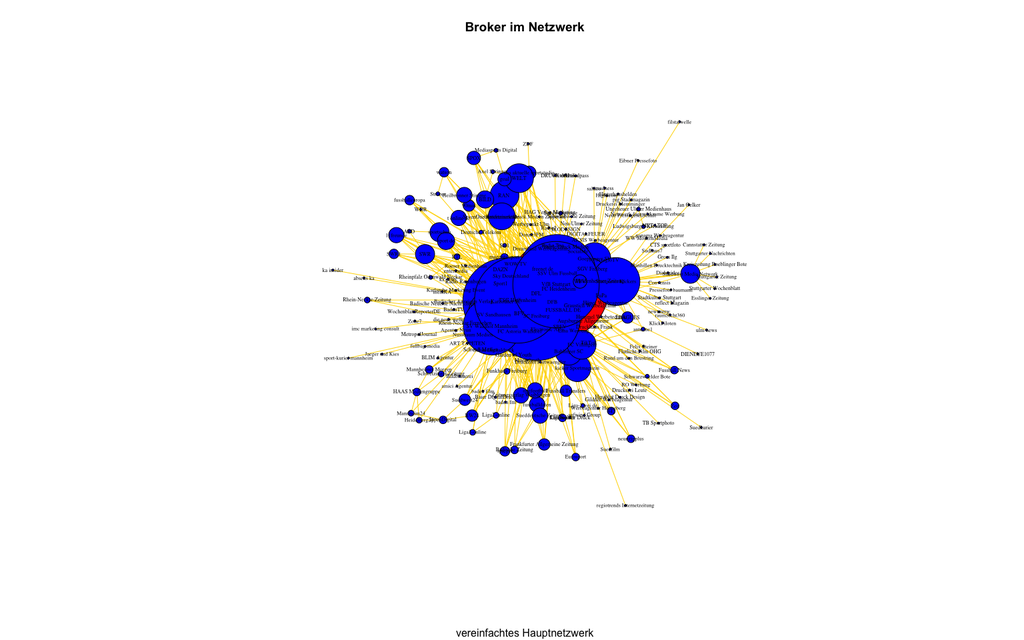

```r
# Visualisierung mit igraph
plot(footballmedia,
     asp=1,
     vertex.label.cex=0.5,
     layout=layout_with_kk,
     main ="Broker im Netzwerk", sub = "vereinfachtes Hauptnetzwerk")
```

```r
# Als PNG speichern
png("footballmedia_betweenness.png", width = 2000, height = 2000, res = 300)
plot(footballmedia,
     asp=1,
     vertex.label.cex=0.5,
     layout=layout_with_kk,
     main ="Broker im Netzwerk", sub = "vereinfachtes Hauptnetzwerk")
dev.off()
```

Die Ergebnisse zeigen:

- Im Gesamtnetzwerk hat der „WFV“ mit einem Wert von 0,346 die höchste Betweenness-Zentralität. Dies ist nachvollziehbar, da der Verband mit den meisten untersuchten Vereinen verbunden ist und somit als Hauptvermittler agiert.
- Im Teilnetzwerk der Profivereine weist die „DFL“ mit einem Wert von 0,344 die höchste Betweenness-Zentralität auf. Da alle Profivereine mit der DFL verknüpft sind, übernimmt diese eine ähnliche Vermittlungsrolle wie der WFV im Gesamtnetzwerk.
- Im Teilnetzwerk der Amateurvereine nimmt überraschenderweise der Streamingdienst „LEAGUES“ die Spitzenposition mit einem Wert von 0,40 ein. Dies erklärt sich durch seine zentrale Rolle in der Regionalliga, da die meisten Amateurvereine in dieser Liga spielen und über den Dienst übertragen werden. Somit laufen viele Verbindungen über diesen Akteur.

Die Ergebnisse bestätigen meine Hypothese, dass zentrale Verbände wie der WFV und die DFL im Profibereich eine koordinierende und vernetzende Funktion innehaben. Im Amateurbereich zeigt sich jedoch ein interessanter Unterschied: Hier tritt kein Verband, sondern ein externer Akteur (LEAGUES) als zentraler Vermittler auf, was die Abhängigkeit der Amateurvereine von spezifischen Medien- und Streamingdiensten betont.

### 3.5.3 Closeness

Die **Closeness-Zentralität** gibt an, wie eng ein Knoten mit anderen Akteuren im Netzwerk verbunden ist. Sie zeigt, welche Akteure schnell und effizient mit anderen Knoten interagieren können.

```r
# Closeness
?closeness

# Netzwerk neu einlesen
library(igraph)
library(visNetwork)

# Berechung des Closeness-Werts
close <- closeness(footballmedia, mode="all", normalized=TRUE)
close
```

```
##          Rund um den Brustring                   Vertikalpass
##                     0.13496933                     0.13496933
##                   vfb exklusiv                    ART TAPETEN
##                     0.13496933                     0.15034169
##             Baier DigitalDruck            Bairle Druck Medien
##                     0.13270777                     0.15714286
##                     DRUCKtuell                Druckhaus Frank
##                     0.13496933                     0.15714286
##         Druckerei Furtwaengler                       Grom Ilg
##                     0.15102975                     0.14306358
##            Hummel Werbetechnik              Kniebuehler Druck
##                     0.15714286                     0.12975098
##                Druckerei Leute         Manhillen Drucktechnik
##                     0.12983607                     0.14306358
##            Druckerei Memminger                     RO Werbung
##                     0.13904494                     0.12975098
##             Schaa Digitaldruck                 Schwall Medien
##                     0.15102975                     0.15034169
##                 Werbepunkt Ulm         Druck Medien Zipperlen
##                     0.15384615                     0.15384615
##                     baden film             Pressefoto baumann
##                     0.13200000                     0.14306358
##                   Bildbrauerei                  CTS sportfoto
##                     0.13711911                     0.14306358
##              Eibner Pressefoto                     entermedia
##                     0.12290503                     0.15034169
##             Flutlicht-Film OHG                Jaeger und Kies
##                     0.13496933                     0.12065814
##                 WW ModernMedia                   raumSicht360
##                     0.14306358                     0.14306358
##                       Suedfilm                  Felix Steiner
##                     0.11498258                     0.13589568
##                  TB Sportphoto                          Zone7
##                     0.11498258                     0.13711911
##                Electronic Arts                   Agentur Neun
##                     0.16995708                     0.15034169
##                  amici Agentur                   BLIM Agentur
##                     0.13129973                     0.13711911
##                      Convensis                   DIGITALFEUER
##                     0.14306358                     0.15384615
```

[output cut: 145 more lines]

```
##                     0.18032787                     0.22863741
##                   FC Villingen                  Goeppinger SV
##                     0.17506631                     0.19411765
##                  Karlsruher SC                           SBFV
##                     0.21451788                     0.20603538
##                    SC Freiburg                   SGV Freiberg
##                     0.21592148                     0.19223301
##            Stuttgarter Kickers                  SV Sandhausen
##                     0.20000000                     0.18750000
##            SV Waldhof Mannheim                 TSG Hoffenheim
##                     0.18857143                     0.21405405
##               SSV Ulm Fussball                  VfB Stuttgart
##                     0.22172452                     0.22602740
##                            WFV
##                     0.23294118
```

```r
# Selektierung der Knoten mit dem höchsten bzw. niedrigsten Closeness-Wert
which.max(close)
```

```
## WFV
## 199
```

```r
which.min(close)
```

```
## regiotrends Internetzeitung
##                         156
```

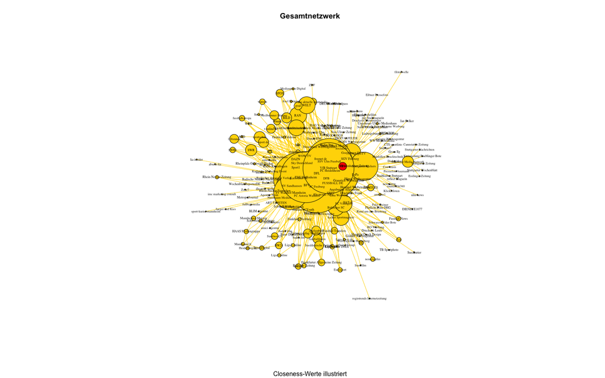

```r
# Anpassung der Farbe von Knoten, Kanten und Beschriftungen
V(footballmedia)$color <- "gold"
E(footballmedia)$color <- "gold"
V(footballmedia)$label.color <- "black"

# Anpassung der Farbe der Knoten mit dem höchsten bzw. niedrigsten Closeness-Wert
V(footballmedia)[V(footballmedia)$name == "WFV"]$color <- "red"
V(footballmedia)[V(footballmedia)$name == "regiotrends Internetzeitung"]$color <- "green"

# Visualisierung mit igraph
plot(footballmedia,
     asp=1,
     vertex.label.cex=0.5,
     layout=layout_with_kk,
     main ="Gesamtnetzwerk", sub = "Closeness-Werte illustriert")
```

```r
# Als PNG speichern
png("footballmedia_closeness.png", width = 2000, height = 2000, res = 300)
plot(footballmedia,
     asp=1,
     vertex.label.cex=0.5,
     layout=layout_with_kk,
     main ="Gesamtnetzwerk", sub = "Closeness-Werte illustriert")
dev.off()
```

- Der „WFV“ hat mit 23,29% die höchste Closeness-Zentralität im Gesamtnetzwerk. Dies liegt nahe, da er durch seine Rolle als Verband viele direkte Verbindungen aufweist und somit ein zentraler Akteur ist.
- Der Knoten mit der geringsten Closeness-Zentralität ist die „regiotrends Internetzeitung“ mit 9,35%. Dies erklärt sich durch ihre geringe Vernetzung, da sie lediglich eine schwache Verbindung zum „Bahlinger SC“ aufweist, einem der am wenigsten zentralen Vereine.

Die Ergebnisse zeigen, dass Closeness und Betweenness eng miteinander korrelieren, da Akteure mit vielen Verbindungen (wie der WFV) sowohl als Brücken fungieren als auch eng mit dem Netzwerk verknüpft sind.